# Pitcher card

# Seth Lugo

RHP · KC

2026 · 32 G (32 GS) · 2,794 pitches · Mar 29 – Sep 23, 2026

Independent portfolio sample by Devin Jenkinson, not affiliated with any club. Every number is computed from public Statcast data.

Three big takeaways

1Attack

The cutter is the put-away pitch. Use it to finish at-bats.

22% of two-strike pitches · 21% whiffs/swing (107 swings)

It grades 86 Stuff+. Next best two-strike miss rate: the curveball at 19%.

2Avoid

Limit the 4-seam fastball. It is his most damaging pitch.

xRV/100 -0.66 shrunk (raw -0.97) · .450 xwOBAcon · 468 pitches

When behind in the count he throws it 16% of the time; the cutter grades -0.11 there instead.

3Watch

Elevate the sinker. Hitters miss it up.

19% whiffs up (53 sw) vs 10% down (86 sw) · VAA -5.6°

27% of his sinkers finish in the top third of the zone and 44% in the bottom third.

Charts

### Movement

The CU finishes 39 in from his SI, with 32 in more glove-side run.

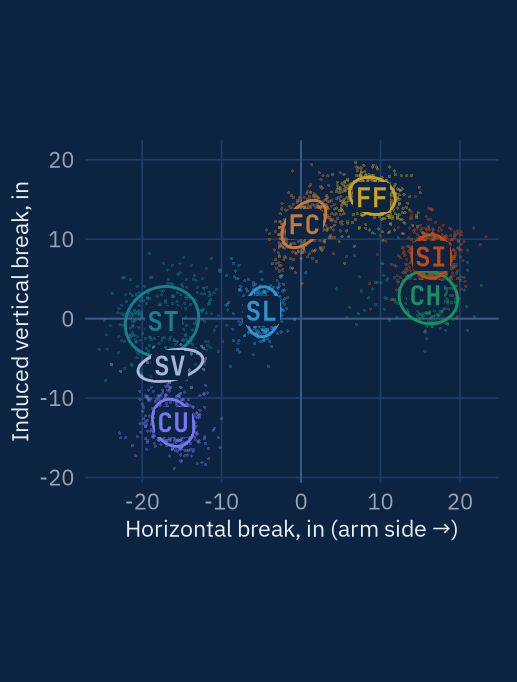

n = 2,794 pitches. Ellipses hold about 68% of each type; codes sit at the averages.

### Location by count

He throws 61% of pitches in the zone when behind and 43% when ahead.

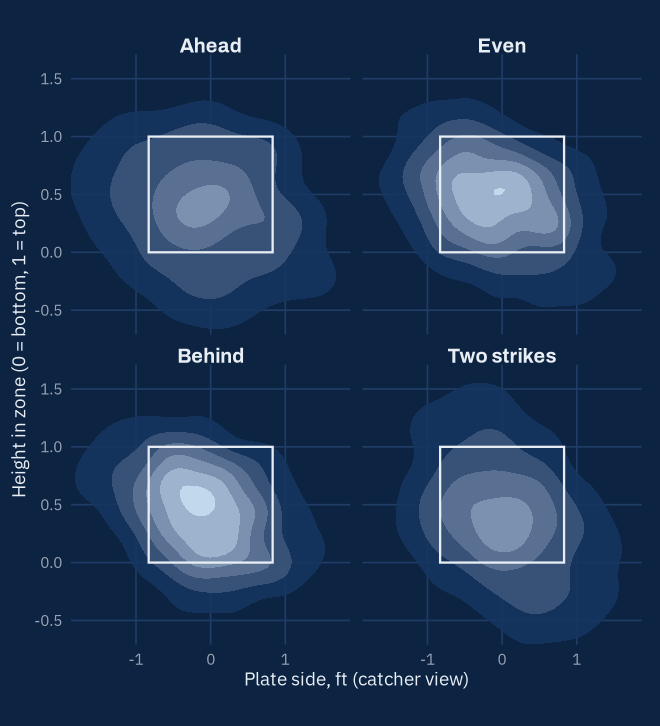

n = 2,794. Ahead 364 · even 1041 · behind 606 · two strikes 783 pitches. Box = rule-book zone.

### Put-away

The FC is 22% of two-strike pitches vs 16% overall.

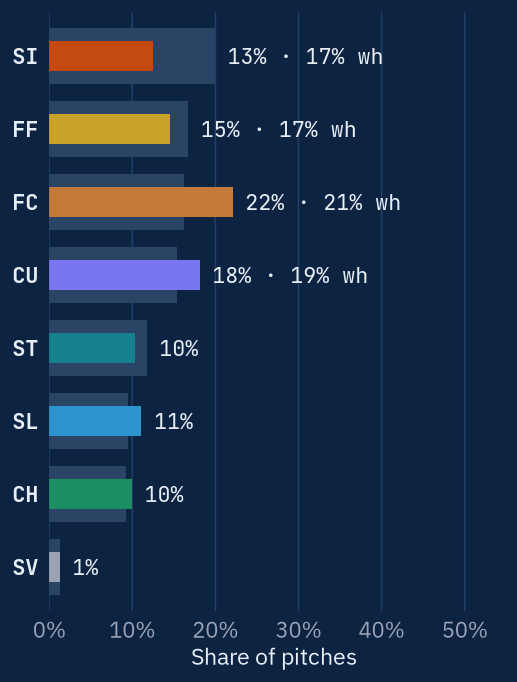

Two-strike n: FC 173, CU 142, FF 114, SI 98, SL 87, ST 81, CH 78, SV 10. Grey bars = overall usage; wh = whiffs per swing (shown with 50+ swings).

### Arsenal

| Pitch | # | Use | Velo | IVB | HB | VAA | Whiff | Chase | xwOBAcon | xRV/100 | Stuff+ |
| --- | --- | --- | --- | --- | --- | --- | --- | --- | --- | --- | --- |
| Sinker (SI) | 558 | 20% | 91.4 | 7.8 | +16.4 | -5.6 | 12% | 16% | .410 | -0.18 | 91 |
| 4-Seam (FF) | 468 | 17% | 91.7 | 15.3 | +8.9 | -4.8 | 15% | 22% | .450 | -0.66 | 78 |
| Cutter (FC) | 454 | 16% | 89.8 | 11.9 | +0.4 | -5.2 | 24% | 22% | .404 | -0.11 | 86 |
| Curveball (CU) | 430 | 15% | 77.3 | -13.0 | -16.1 | -9.8 | 22% | 33% | .335 | -0.22 | 101 |
| Sweeper (ST) | 328 | 12% | 79.2 | -0.3 | -17.3 | -7.6 | 16% | 29% | .373 | -0.65 | 106 |
| Slider (SL) | 264 | 9% | 84.3 | 1.0 | -5.0 | -7.7 | 23% | 25% | .385 | -0.12 | 101 |
| Changeup (CH) | 257 | 9% | 85.1 | 3.0 | +15.7 | -7.2 | 16% | 28% | .352 | -0.34 | 93 |
| Slurve (SV) | 35 | 1% | 77.3 | -5.9 | -16.5 | -8.6 | 19% | 29% | .332 | -0.07 | 103 |

IVB / HB in inches (HB + = arm side). VAA in degrees at the front of the plate. xRV/100 = expected run value per 100 pitches, pitcher’s view, shrunk with a 250-pitch prior. Stuff+ = this project’s shape-only model (100 = MLB average, 10 = 1 SD).

### Vs. batter hand

| Pitch | LHH # | Use | Whiff | xwOBAcon | RHH # | Use | Whiff | xwOBAcon |
| --- | --- | --- | --- | --- | --- | --- | --- | --- |
| SI | 337 | 18% | 14% | .420 | 221 | 23% | 11% | .379 |
| FF | 319 | 18% | 16% | .398 | 149 | 15% | 13% | .337 |
| FC | 318 | 17% | 25% | .326 | 136 | 14% | 23% | .388 |
| CU | 346 | 19% | 19% | .296 | 84 | 9% | – | .268 |
| ST | 162 | 9% | 13% | .451 | 166 | 17% | 19% | .280 |
| SL | 98 | 5% | – | .294 | 166 | 17% | 22% | .314 |
| CH | 231 | 13% | 17% | .322 | 26 | 3% | – | .309 |
| SV | 11 | 1% | – | .698 | 24 | 2% | – | .299 |

Use = share of pitches to that side. Whiff = whiffs per swing, shown with 50+ swings.